# Engagement of Organizations on Open AI Repositories

Augustina Ragwitz

June 21, 2018

# Question

Concerning open source engagement, are companies engaging more in their own projects than in external ones? Are companies collaborating or working in isolation? Note, this analysis specifically focuses on Artificial Intelligence and Data Science projects.

The source code for this notebook is available on [Github](https://github.com/countering-bean-counting/internal-vs-external-engagement/blob/master/ai-dl_repos/ai-dl_repos.Rmd).

If you’d like to play with your own summaries, the summary data used for the analysis is available [here](https://github.com/countering-bean-counting/internal-vs-external-engagement/blob/master/ai-dl_repos/data/repo_engagement.csv).

# Data

The data come from other analysis, detailed below.

## Projects of Interest

Git commit logs were taken for 6 months by cloning a manually curated list of projects.

From [Countering Bean Counting - Git Commit Log Engagement Analysis](https://github.com/countering-bean-counting/countering-bean-counting/git-commit-log-engagement/blob/master/deep-learning-frameworks-commit-log/dl-frameworks-commit-log.Rmd)

```r
# manual list of sponsored projects
sponsored_projects <- read_csv('
tensorflow,Google,open
paddlepaddle,Baidu,open
pytorch,Facebook,open
keras-team,Google,open
ibm,IBM,closed
microsoft,Microsoft,closed
apple,Apple,closed
aws,Amazon.com,closed
h2oai,H2O,open
uber,Uber,closed
intel-analytics,Intel,closed
', col_names=c("project","sponsor","commit_access"))

# Github Repositories
repos_open <- read_rds("imported_data/repos_open.Rds")

repos_open <- repos_open %>%
  separate(repo, into=c("project", "repo_short"), sep="/", remove=FALSE) %>%
  mutate(project=str_to_lower(project)) %>%
  left_join(sponsored_projects) %>%
  mutate(commit_access=ifelse(is.na(commit_access), "open", commit_access))

# Commit Log for Repositories (last 6 months)
gitlog_open_projects <- read_rds("imported_data/commit_log_open_Jun2018.Rds")

gitlog_open_projects <- gitlog_open_projects %>%
  select(project=org,
         repo,
         commit_month,
         author_name, author_email,
         committer_name, committer_email,
         sha,
         committer_company_name, committer_company_type,
         author_company_name, author_company_type)
```

## Companies of Interest

Commit logs were retrieved via the Github API for all Gihub repositories listed for a manually curated list of companies of interest. The company Github organizations were manually identified on Github.

From [Countering Bean Counting - Organization Repository Analysis](https://github.com/countering-bean-counting/countering-bean-counting/organization-repo-analysis/blob/master/org_by_repo_summary.Rmd)

```r
# Github Repositories
repos_closed <- read_rds("imported_data/repos_closed.Rds")

repos_closed <- repos_closed %>%
  select(project=github_org, repo=full_name, repo_short=name, description, sponsor=company) %>%
  mutate(commit_access = "closed",
         # misspelled Red Hat in original
         sponsor=str_replace(sponsor, "Redhat", "Red Hat"))

# Commit Log for Repositories (last 6 months)
gitlog_closed_projects <- read_rds("imported_data/commit_log_closed_Jun2018.Rds")

gitlog_closed_projects <- gitlog_closed_projects %>%
  select(project=github_org,
         repo,
         commit.committer.date,
         # author_name=commit.author.name, author_email=commit.author.email, author_login=author.login,
         committer_name=commit.committer.name, committer_email=commit.committer.email, committer_login=committer.login,
         sha,
         committer_company_name=company) %>%
 mutate(commit_month=floor_date(as.Date(commit.committer.date), unit="months")) %>%
 select(-commit.committer.date) %>%
  filter(commit_month > "2017-12-01")

# Commit Activity for Contributors to the Company Repositories Above
# affliated_commits_closed <- read_rds("imported_data/commit_activity_closed_Jun2018.Rds")
```

## Combined Repo List

Make a consolidated list of repos and add information about whether it’s a company-owned or public repository.

```r
repos <- bind_rows(repos_open, repos_closed)
```

## Consolidated Commit Logs

Combine the commit logs.

```r
# bind rows on commit logs
gitlog <- bind_rows(gitlog_closed_projects, gitlog_open_projects)
```

## Verify Company Distribution for Closed Projects

Closed projects come from official company repositories. The assumption for this analysis is that committers to these projects are employees of the company, or some other way affiliated in an official capacity. The following plots show the distribution of the committers on these repositories.

Note that identification is really hard and these plots will show how much obfuscation exists even on mostly known repositories.

```r
company_id_lookup <- bind_rows(
  gitlog_open_projects %>% select(company_name=author_company_name, email=author_email) %>% unique(),
  gitlog_open_projects %>% select(company_name=committer_company_name, email=committer_email) %>% unique())

company_id_lookup <- company_id_lookup %>%
  separate(email, c("user", "email_host"), sep="@") %>%
  mutate(email_domain = suffix_extract(email_host)$domain) %>%
  select(-user, -email_host) %>%
  unique() %>%
  filter(! is.na(company_name))

# manually add missing ones
missing_companies <- read_csv('
Pivotal,pivotal
Oracle,oracle
AT&T,attlocal
AT&T,att
Huawei,huawei
', col_names=c("company_name", "email_domain"))

company_id_lookup <- bind_rows(company_id_lookup, missing_companies)

project_contributors <-  gitlog %>%
  select(project, repo, author_email, committer_email, activity_month=commit_month, sha) %>%
  unite(email, author_email, committer_email) %>%
  separate_rows(email, sep="_", convert=TRUE) %>%
  filter(! is.na(email)) # filter out entries with no email, will double check for missing in the next step

# get missing sha's (committer is na)
missing_contributors <- project_contributors %>%
  anti_join(gitlog %>% select(sha))

print(paste("Missing Contributors:", nrow(missing_contributors)))
```

```
## [1] "Missing Contributors: 0"
```

```r
# match email domains to lookup list
project_contributors <- project_contributors %>%
  separate(email, c("user", "email_host"), sep="@", remove=FALSE) %>%
  mutate(email_domain = suffix_extract(email_host)$domain) %>%
  select(-user) %>%
  left_join(company_id_lookup) %>%
  unique()

# add repo data

project_contributors_join <- project_contributors %>%
  left_join(repos)

# set domain type

project_contributors_join <- project_contributors_join %>%
  mutate(domain_type = ifelse(is.na(company_name), "No Domain Info",
                              ifelse(str_detect(company_name, " Email"), "Personal",
                                     ifelse(company_name == sponsor, "Employee",
                                            ifelse(company_name == "GitHub", "GitHub",
                                                   "Other Organization")))))
```

```r
project_contributors_sponsor_summary <- project_contributors_join %>%
  group_by(commit_access, sponsor, project) %>%
  mutate(total_commits=n()) %>%
  group_by(commit_access, sponsor, project, domain_type) %>%
  summarise(num_commits=n(),
            pct_commits=round(num_commits/first(total_commits), 3),
            total_commits=first(total_commits))

project_contributors_company_summary <- project_contributors_join %>%
  group_by(commit_access, sponsor, project) %>%
  mutate(total_commits=n()) %>%
  group_by(commit_access, sponsor, project, domain_type, company_name) %>%
  summarise(num_commits=n(),
            pct_commits=round(num_commits/first(total_commits), 3),
            total_commits=first(total_commits))
```

### Distribution of Committers by Domain on Closed Projects

#### What email addresses were used by committers on closed projects?

What proportion of committers on the company projects used their work email address? What types of email addresses were otherwise used?

The majority of activity came from employee email addresses, Github obfuscated (also comes from direct commits through the Github Web UI), or no domain info. No domain information typically happens when commits are entered through an automated build system, usually internal to the company, or the repository is mirrored. Overall the presence of “Other Domain” is very minimal. This supports the assumption that the majority of committers on Company-sponsored, closed projects are likely acting in some official capacity for the sponsoring company.

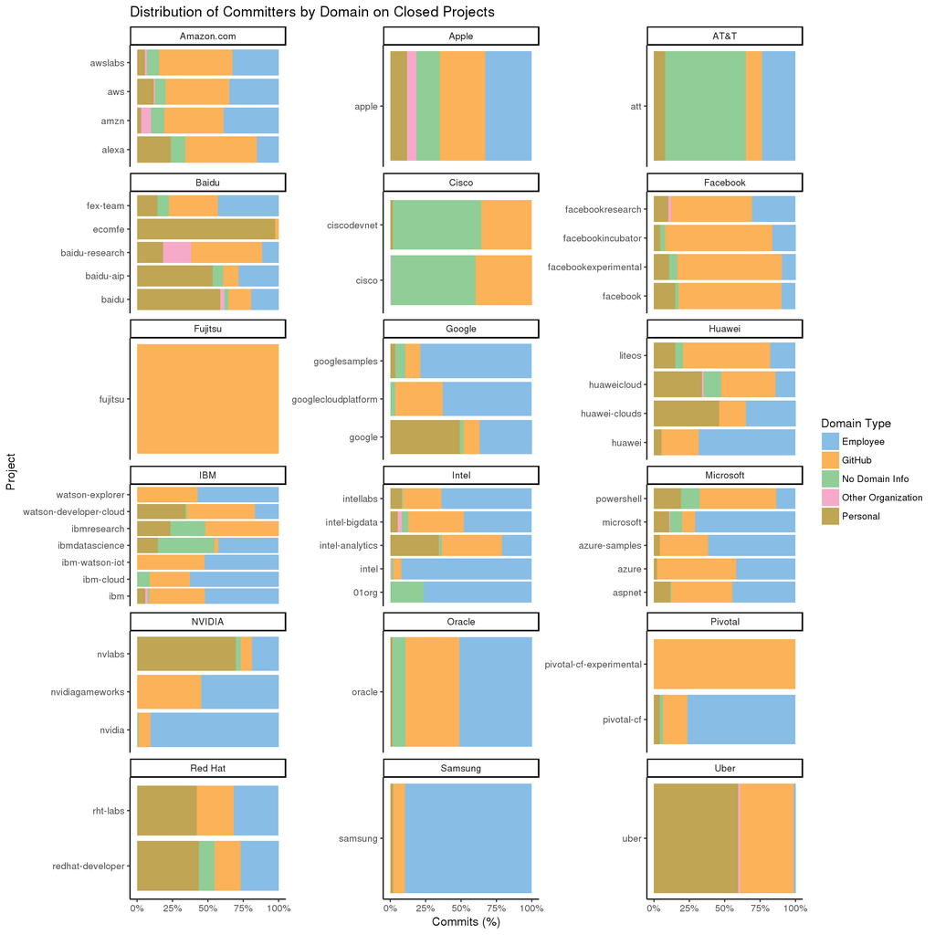

```r
ggplot(project_contributors_sponsor_summary %>% filter(commit_access == "closed"),
       aes(x=project,
           y=pct_commits)) +
  geom_bar(aes(fill=domain_type), stat="identity") +
  scale_y_continuous(labels=percent) +
  labs(x="Project", y="Commits (%)", fill="Domain Type",
       title="Distribution of Committers by Domain on Closed Projects") +
  coord_flip() +
  facet_wrap(~ sponsor, scales="free_y", ncol=3) +
  theme_classic() +
  scale_fill_few()
```

#### How significant was the contribution on closed projects from external organizations?

Does it invalidate our assumption about committers being affiliated in an official capacity?

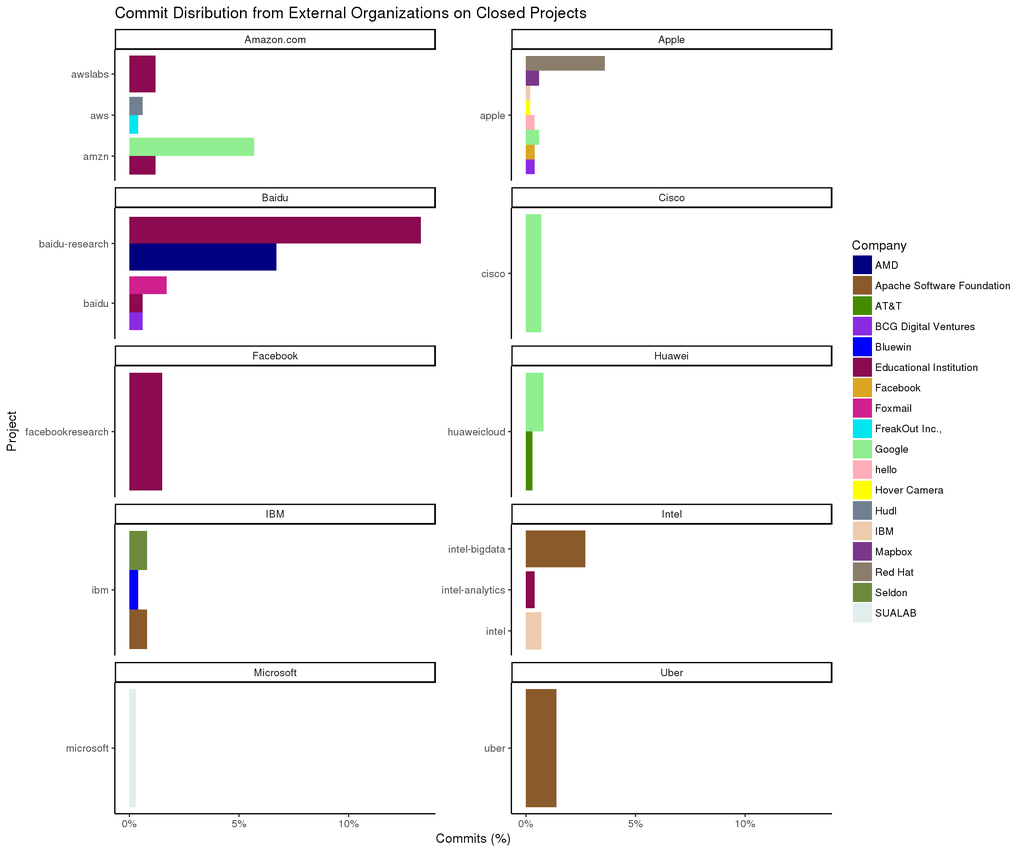

```r
closed_projects_ext_orgs <- project_contributors_company_summary %>%
  filter(commit_access == "closed" & domain_type == "Other Organization") %>%
  # group education institutions
  mutate(company_name = ifelse(str_detect(company_name, "University|UC|Institute"), "Educational Institution", company_name))


ggplot(closed_projects_ext_orgs,
       aes(x=project,
           y=pct_commits)) +
  geom_bar(aes(fill=company_name), stat="identity", position="dodge") +
  scale_y_continuous(labels=percent) +
  labs(x="Project", y="Commits (%)", fill="Company",
       title="Commit Disribution from External Organizations on Closed Projects") +
  coord_flip() +
  facet_wrap(~ sponsor, scales="free_y", ncol=2) +
  theme_classic() +
  scale_fill_manual(values=ggplot_scale)
```

## Engagement Score

The Engagement Score attempts to measure companies engaging in open source projects based on the length of time they have been involved with a project and the significance of their contributions. The length of time is the most important factor in this score while the commit weight provides a small indication for comparison when the involvement over time is fairly similar between two groups.

Engagement metrics are defined as follows:

- Activity Months - Number of months that had at least one commit from an affiliated email address
- Commit Weight - Rounded natural log of the number of commits from an affiliated email address per month

The Engagement Score adjusts the above metrics as follows:

- Months Percent - Proportion of total months with commits in the range considered for the report. For example, this report analyzes 6 months of data, so the proportion would be the number of months with an affiliated commit out of 6 months.
- Commit Weight - Takes the mode of the Commit Weight (most frequently occurring Commit Weight over the range analyzed) and divides it by 50 to better scale with the percent value being used.

The engagement score is multiplied by 100 to make it more “score-like” but that is just cosmetic.

```r
# Consolidate author + committer (ok if counted twice -- this shows an increased interest in the project)

# create a lookup for company type so we don't have to deal with it in the summary below
company_type_lookup <- bind_rows(gitlog %>% select(company_name=author_company_name, company_type=author_company_type),
                                 gitlog %>% select(company_name=committer_company_name, company_type=committer_company_type))

company_type_lookup <- company_type_lookup %>%
  unique() %>%
  filter(! is.na(company_type))

repo_summary <- project_contributors_join %>%
  group_by(project, repo, company_name, activity_month) %>%
  summarize(commits=n(),
             # natural log provides a simple weight
            commit_weight = round(log(commits))) %>%
  group_by(project, repo, company_name, commit_weight) %>%
  mutate(commit_weight_mode = n()) # for computing the mode

# determine the typical commit pattern from each company by finding the most frequent weight (mean or median could also work)
repo_engagement <- repo_summary %>%
  group_by(project, repo, company_name) %>%
  summarize(
    activity_months = n_distinct(activity_month), # number of months with a commit
    commit_weight = commit_weight[which.max(commit_weight_mode)] # commit weight mode
  )

# maximum months possible in the sample, used to determine percent of months
activity_months_max <- max(repo_engagement$activity_months)

repo_engagement <- repo_engagement %>%
  # proportion of months with a commit
  mutate(months_pct = round(activity_months/activity_months_max, 1),
         # adjust the weight so it fits better with percent, multiply by 100 to make it more "score-like"
         engagement_score = 100 * (months_pct + commit_weight/50)) %>%
  # add company type
  inner_join(company_type_lookup)

# add repo data for plotting
repo_engagement <- repo_engagement %>%
  left_join(repos %>% select(-description) %>% unique())

# Clean up NA's, remove this once further identify steps taken above
repo_engagement <- repo_engagement %>%
  # filter out authors on closed repos, I haven't identified them yet so they are all NA
  filter(! (is.na(company_name) & commit_access == "closed")) %>%
  mutate(
    # set company type to public for closed repos (this is for filtering later)
    company_type=ifelse(is.na(company_type) & commit_access == "closed", "public", company_type),
    # lump projects together that don't have an explicit sponsor
    sponsor=ifelse(is.na(sponsor), "Community Project", sponsor),
    # for a better apples-to-apples comparison, call out activity on closed repos where the company email address was used
    activity_scope = ifelse(is.na(company_name) | company_type %in% c("github", "personal"), "unknown", # likely affiliated activity on closed repos
                                 ifelse(company_name == sponsor, "internal", "external"))) %>% # explicit affiliated activity on closed repos
  unique()

write_csv(repo_engagement, "data/repo_engagement.csv")
```

# Analysis

## External vs Internal Engagement

Did companies typically engage more with their own projects than with other projects?

The engagement below has been analyzed at the repository level. The box plots show the distribution of the identified activity.

Closed projects used a different identification assumption than did open projects. Only commit activity from work email addresses has been considered on closed projects to make a better apples-to-apples comparison.

Note also that this is comparing all projects within a companies’ own repositories with a selection of well-known open source AI and data science projects.

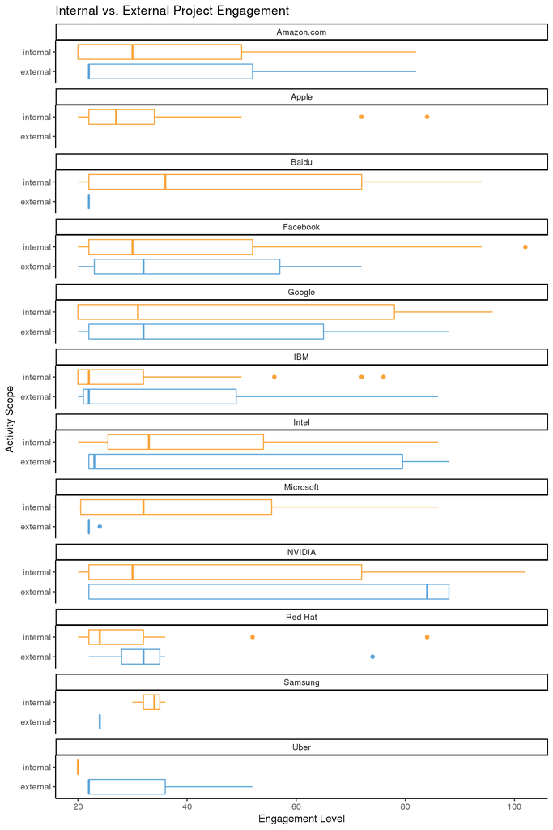

```r
# boxplot
# facet by company
# x = activity_scope, y = engagement score

ggplot(repo_engagement %>% filter(company_name %in% repo_engagement$sponsor),
       aes(x = activity_scope, y = engagement_score)) +
  geom_boxplot(aes(color=activity_scope), show.legend = FALSE) +
  coord_flip() +
  facet_wrap(~ company_name, ncol=1) +
  labs(x="Activity Scope", y="Engagement Level",
       title="Internal vs. External Project Engagement") +
  theme_classic() +
  scale_color_few()
```

## IBM Focus

### IBM vs Microsoft

This section focuses on Microsoft and IBM to test the engagement score and uses the analysis that assumes all activity on an internal repository is “sanctioned”.

```r
engagement_ibm <- repo_engagement %>%
  filter(company_name %in% c("Microsoft", "IBM"))
```

As expected, we see high engagement on the companies’ own projects. Microsoft appears to have broader engagement while IBM is more targeted. For projects IBM has been engaged with, the relationship is much longer than Microsoft’s, suggesting more consistent commit engagement.

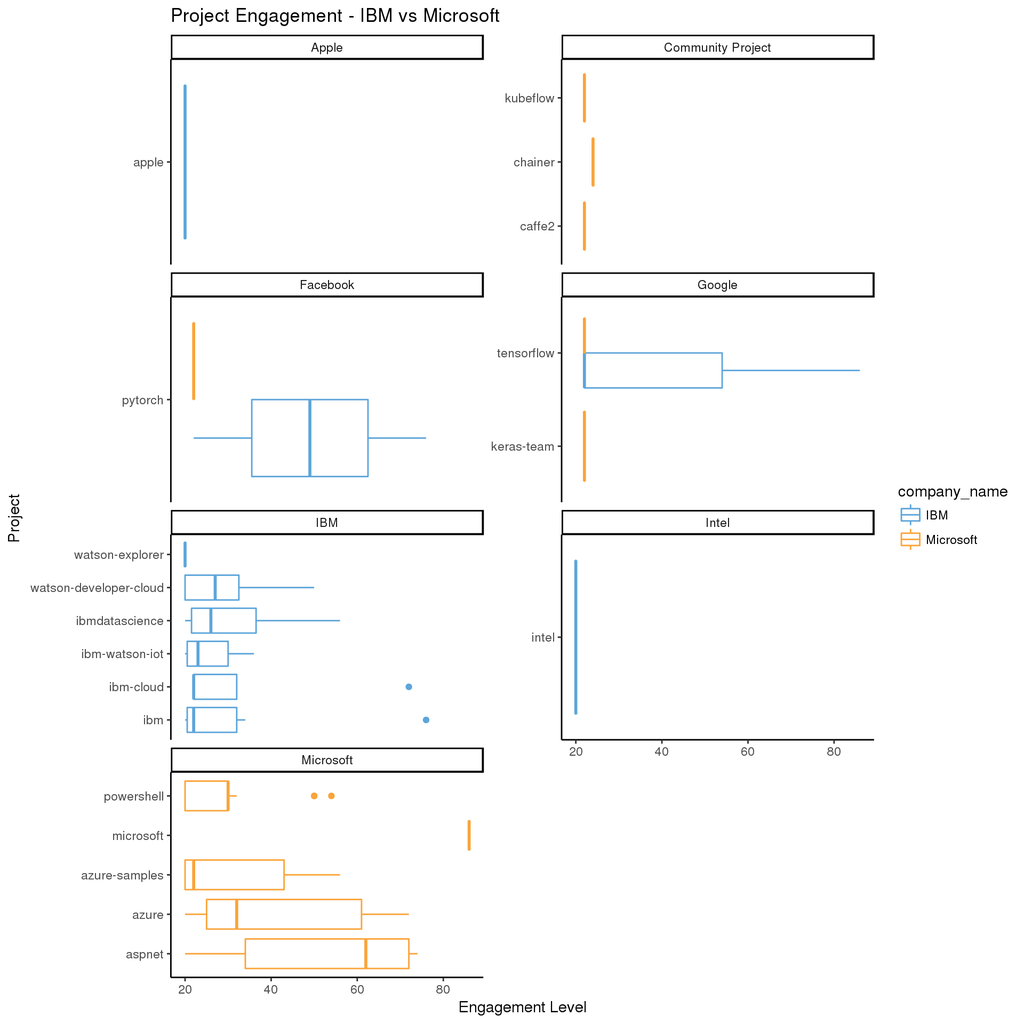

```r
ggplot(engagement_ibm,
       mapping = aes(x = project, y = engagement_score)) +
  geom_boxplot(aes(color = company_name)) +
  coord_flip() +
  facet_wrap(~ sponsor, scales="free_y", ncol=2) +
  labs(x="Project", y="Engagement Level", fill="Contributing Company",
       title="Project Engagement - IBM vs Microsoft") +
  theme_classic() +
  scale_color_few()
```

The following plot groups the external engagement into one plot for easier comparison. This supports the observation above – IBM tends to have longer, more consistent engagements while Microsoft tends to be more broad.

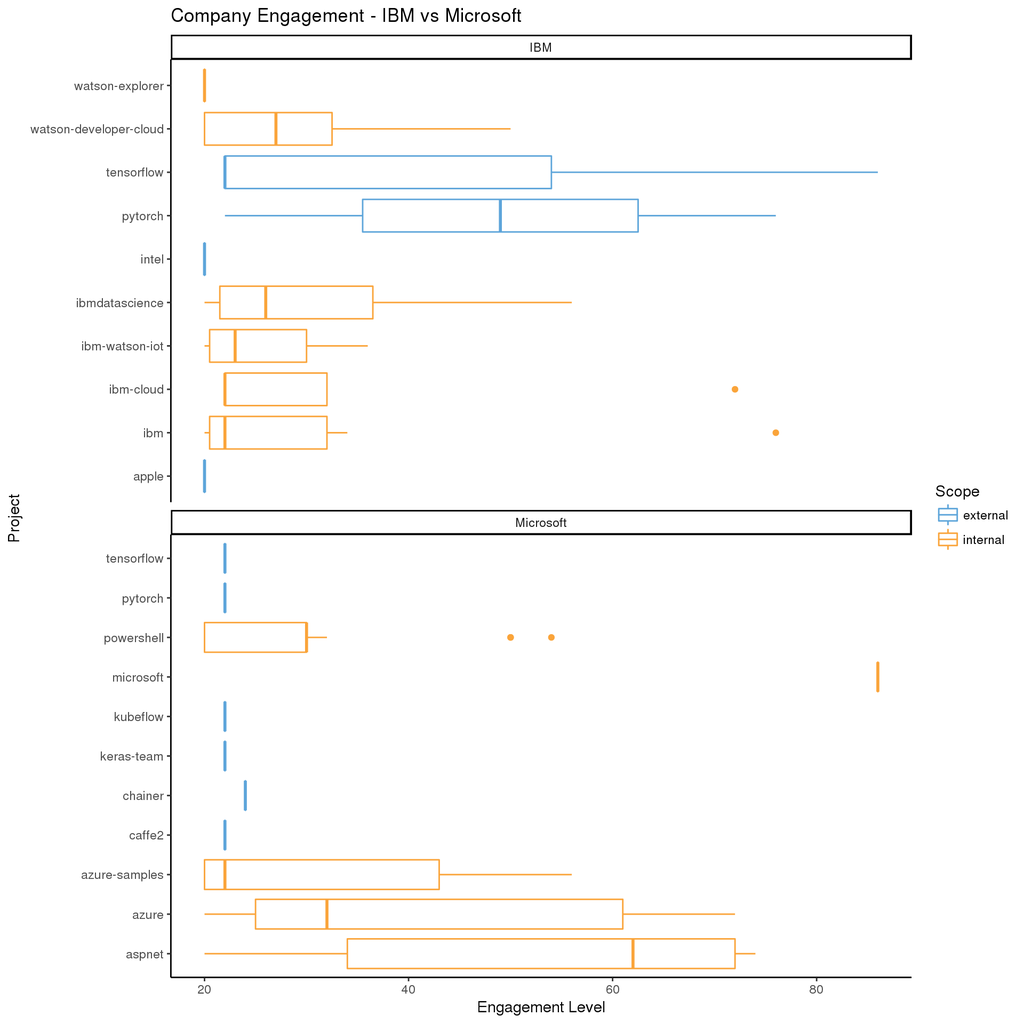

```r
ggplot(engagement_ibm,
       mapping = aes(x = project, y = engagement_score)) +
  geom_boxplot(aes(color = activity_scope)) +
  coord_flip() +
  facet_wrap(~ company_name, scales="free_y", ncol=1) +
  labs(x="Project", y="Engagement Level", color="Scope",
       title="Company Engagement - IBM vs Microsoft") +
  theme_classic() +
  scale_color_few()
```

The following plot is a simpler view of all repository activity summarized by project.

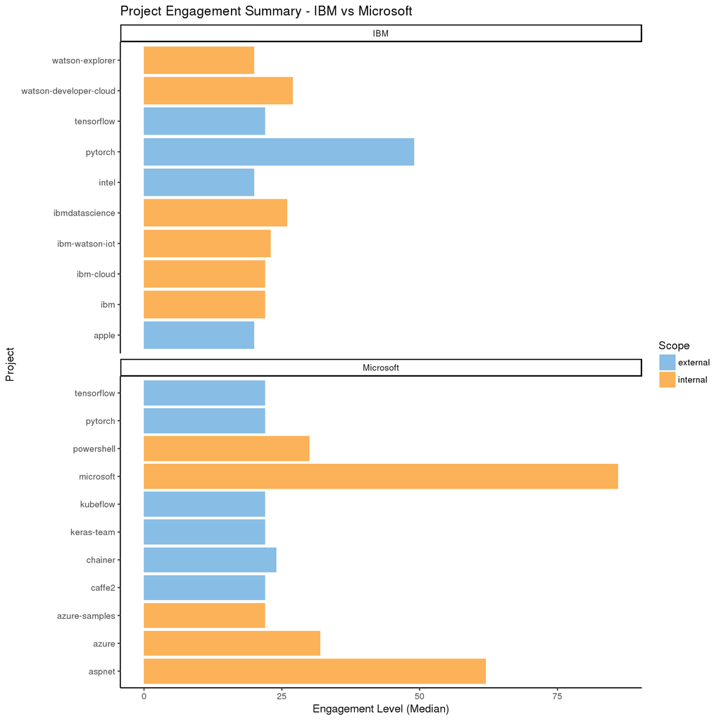

```r
# summarise engagement score for each project
engagement_ibm_summary <- engagement_ibm %>%
  group_by(company_name, activity_scope, project) %>%
  summarise(engagement_score_med = median(engagement_score))

ggplot(engagement_ibm_summary,
       mapping = aes(x = project, y = engagement_score_med)) +
  geom_bar(aes(fill = activity_scope), stat="identity", position="dodge") +
  coord_flip() +
  facet_wrap(~ company_name, scales="free_y", ncol=1) +
  labs(x="Project", y="Engagement Level (Median)", fill="Scope",
       title="Project Engagement Summary - IBM vs Microsoft") +
  theme_classic() +
  scale_fill_few()
```

## IBM Engagement Overlap

Where does IBM’s engagment overlap and how does it compare with other companies? According the plot below, IBM shows the most overlap on the Tensorflow and Pytorch projects.

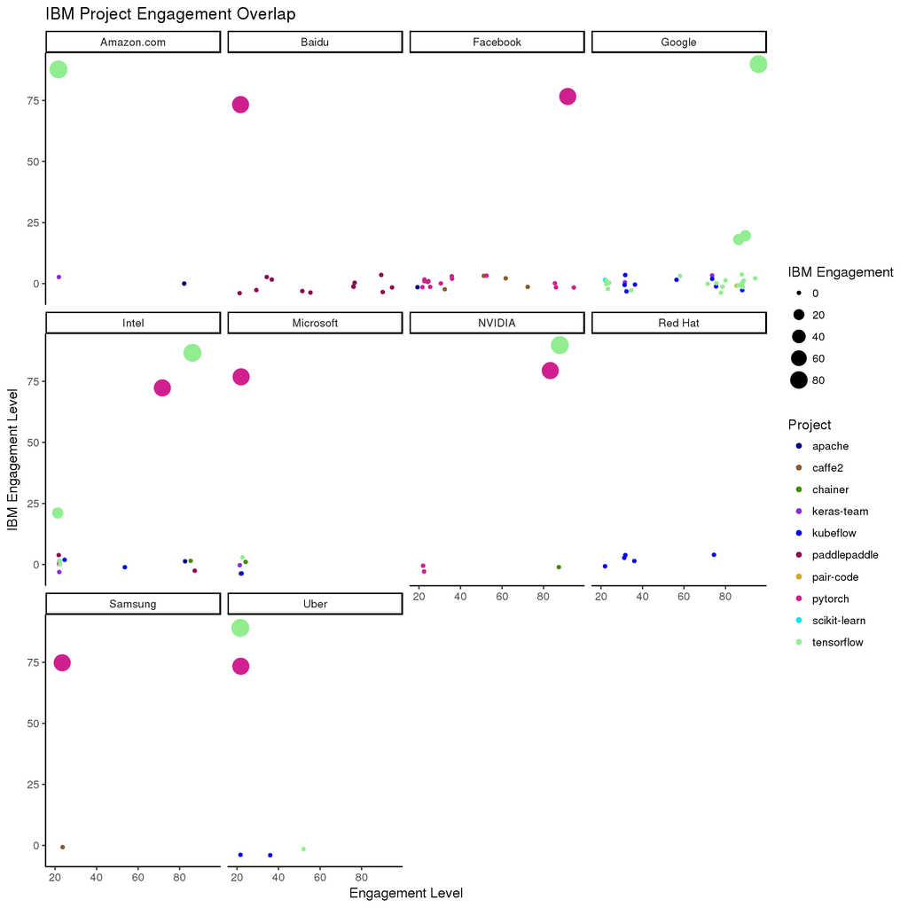

```r
engagement_public <- repo_engagement %>%
  filter(company_name %in% repo_engagement$sponsor) %>%
  mutate(sponsor=ifelse(is.na(sponsor), "Community Project", sponsor))

engagement_compared <- engagement_public %>%
  select(project, sponsor, company_name, engagement_score) %>%
  unique() %>%
  # turn company weights into columns
  spread(company_name, engagement_score, fill=0)

engagement_compared_to_ibm <- engagement_public %>%
  filter(company_name != "IBM") %>%
  inner_join(engagement_compared %>% select(IBM, project))

# dot plot
# x - other company engagement
# y - ibm engagement

ggplot(engagement_compared_to_ibm %>% filter(commit_access == "open"),
       aes(x = engagement_score, y = IBM)) +
  geom_jitter (aes(group=project, color=project, size=IBM)) +
  guides(color=guide_legend(ncol=1)) +
  theme_classic() +
  scale_color_manual(values=ggplot_scale) +
  facet_wrap(~ company_name) +
  labs(x="Engagement Level", y="IBM Engagement Level",
       color="Project",
       size="IBM Engagement",
       title="IBM Project Engagement Overlap")
```

# Final Thoughts

One thing this analysis doesn’t show is the additional commit activity from “employees” or “affiliates” identified through activity on the closed projects. There is a lot of noise in the data and I need to filter it based on the “quality” of the repositories. I may need to filter using a “brute force” method where I only include repos that are part of a larger project rather than owned by individuals.

Right now this is only looking at commits, but I want to add other events. How do we measure “pull” to show what organizations are actually getting more engagement back from the community? And what is our engagement “push” vs our engagement “pull”? Where are we investing a lot and not getting a lot back, so we can evaluate a) if we want to continue that investment and b) strategies for getting more “pull” that we can check against these metrics in the future.

I’m also thinking about future versions using a network to show company overlap because I’m really interested to see what companies might be collaborating, in what space.